# Analysis of NOAA Storm Database

## Synopsis

In this analysis we aim to explore the NOAA Storm Database with respect to two questions.

- Across the United States, which type of weather events are most harmful to public health?
- Across the United States, which type of weather events have the greatest economic consequences?

The documentation for the data can be found [here](https://d396qusza40orc.cloudfront.net/repdata%2Fpeer2_doc%2Fpd01016005curr.pdf) and the file downloaded from [here](https://d396qusza40orc.cloudfront.net/repdata%2Fdata%2FStormData.csv.bz2)

### Data Processing

We begin by reading and exploring the csv file from the NOAA Storm Database.

```r
#First we downloaded the file
if(!file.exists("StormData.csv")){download.file("https://d396qusza40orc.cloudfront.net/repdata%2Fdata%2FStormData.csv.bz2","StormData.csv")}
data <- read.csv("StormData.csv")
names(data)
```

```
##  [1] "STATE__"    "BGN_DATE"   "BGN_TIME"   "TIME_ZONE"  "COUNTY"
##  [6] "COUNTYNAME" "STATE"      "EVTYPE"     "BGN_RANGE"  "BGN_AZI"
## [11] "BGN_LOCATI" "END_DATE"   "END_TIME"   "COUNTY_END" "COUNTYENDN"
## [16] "END_RANGE"  "END_AZI"    "END_LOCATI" "LENGTH"     "WIDTH"
## [21] "F"          "MAG"        "FATALITIES" "INJURIES"   "PROPDMG"
## [26] "PROPDMGEXP" "CROPDMG"    "CROPDMGEXP" "WFO"        "STATEOFFIC"
## [31] "ZONENAMES"  "LATITUDE"   "LONGITUDE"  "LATITUDE_E" "LONGITUDE_"
## [36] "REMARKS"    "REFNUM"
```

```r
head(data)
```

```
##   STATE__           BGN_DATE BGN_TIME TIME_ZONE COUNTY COUNTYNAME STATE
## 1       1  4/18/1950 0:00:00     0130       CST     97     MOBILE    AL
## 2       1  4/18/1950 0:00:00     0145       CST      3    BALDWIN    AL
## 3       1  2/20/1951 0:00:00     1600       CST     57    FAYETTE    AL
## 4       1   6/8/1951 0:00:00     0900       CST     89    MADISON    AL
## 5       1 11/15/1951 0:00:00     1500       CST     43    CULLMAN    AL
## 6       1 11/15/1951 0:00:00     2000       CST     77 LAUDERDALE    AL
##    EVTYPE BGN_RANGE BGN_AZI BGN_LOCATI END_DATE END_TIME COUNTY_END
## 1 TORNADO         0                                               0
## 2 TORNADO         0                                               0
## 3 TORNADO         0                                               0
## 4 TORNADO         0                                               0
## 5 TORNADO         0                                               0
## 6 TORNADO         0                                               0
##   COUNTYENDN END_RANGE END_AZI END_LOCATI LENGTH WIDTH F MAG FATALITIES
```

[output cut: 20 more lines]

There does not appear to be any missing values among the data we are interested in.

```r
sum(is.na(data$PROPDMG))
```

```
## [1] 0
```

```r
sum(is.na(data$CROPDMG))
```

```
## [1] 0
```

Since there isn’t any column with the total cost for each storm event, we will have to make one. To do this we will be using the dplyr package.

```r
library(dplyr)
```

```r
#To get a single nummerical value for property damage we
#take the column called PROPDMG and use the multiplier
#in the column PROPDMGEXP to form a new column
data2 <- mutate(data,TPROPDMG = ifelse(PROPDMGEXP%in%c(0,1,2,3,4,5,6,7,8,9),PROPDMG*as.numeric(PROPDMGEXP),ifelse(PROPDMGEXP=="H",PROPDMG*100,ifelse(PROPDMGEXP=="k",PROPDMG*1000,ifelse(PROPDMGEXP=="M",PROPDMG*1000000,ifelse(PROPDMGEXP=="B",PROPDMG*1000000000,PROPDMG))))))
 #Here we do the same as before but for crop damage
data2 <- mutate(data2,TCROPDMG = ifelse(CROPDMGEXP%in%c(0,1,2,3,4,5,6,7,8,9),CROPDMG*as.numeric(CROPDMGEXP),ifelse(CROPDMGEXP=="H",CROPDMG*100,ifelse(CROPDMGEXP=="k",CROPDMG*1000,ifelse(CROPDMGEXP=="M",CROPDMG*1000000,ifelse(CROPDMGEXP=="B",CROPDMG*1000000000,CROPDMG))))))
#Out of these we can now for the column with total damge in one #column
data2 <- mutate(data2,TCASH = TPROPDMG+TCROPDMG)

#With some trial and error we saw that summearize counted some of #the events as different when in fact they were not. So to #counteract this we remove som blank spaces in the EVTYPE column.

type_name <- data2[,"EVTYPE"]
 type_name <- gsub("[[:space:]]","",type_name)
data2$EVTYPE <- make.names(type_name)
```

To investigate the health and monetary cost of storms we create three different data sets. Which contain the summation of injuries,fatalities and total cost for each type of weather event.

```r
data_inj <- group_by(data2,EVTYPE)
data_inj <- summarize(data_inj,INJURIES = sum(INJURIES))
data_inj <- arrange(data_inj,desc(INJURIES))


data_fatal <- group_by(data2,EVTYPE)
data_fatal <- summarize(data_fatal,FATALITIES=sum(FATALITIES))
data_fatal <- arrange(data_fatal, desc(FATALITIES))


data_cash <- group_by(data2,EVTYPE)
data_cash <- summarize(data_cash,TCASH=sum(TCASH))
data_cash <- arrange(data_cash,desc(TCASH))
```

Here we extract the names and numbers for injuries,fatalities and the total cost from different types of storm events.

```r
#Extraction of injuries names and numbers
tot_inj <- sum(data_inj$INJURIES)
slices_inj <- c(data_inj$INJURIES[1:9],sum(data_inj$INJURIES[10:length(data_inj$INJURIES)]))/tot_inj
pct_inj <- round(slices_inj*100)
labs_inj <-  c(data_inj$EVTYPE[1:9],"Residual")
labs_inj <- paste(labs_inj,pct_inj)
labs_inj <- paste(labs_inj,"%",sep="")


#Fatalities names and numbers
slices_fat <- c(data_fatal$FATALITIES[1:5],sum(data_fatal$FATALITIES[6:length(data_fatal$FATALITIES)]))
tot_fat <- sum(data_fatal$FATALITIES)
labs_fat <- c(data_fatal$EVTYPE[1:5],"Residual")
pct_fat <- round(slices_fat*100/tot_fat)
labs_fat <- paste(labs_fat,pct_fat)
labs_fat <- paste(labs_fat,"%",sep="")

#Total monetary damage names and numbers
tot_cash <- sum(data_cash$TCASH)
slices_cash <- c(data_cash$TCASH[1:5],sum(data_cash$TCASH[6:length(data_cash$TCASH)]))
labs_cash <- c(data_cash$EVTYPE[1:5],"RESIDUAL")
pct_cash <- round(slices_cash*100/tot_cash)
labs_cash <- paste(labs_cash,pct_cash)
labs_cash <- paste(labs_cash,"%",sep="")
```

## Results

The storm events causing the greatest amount of injuries is as follows.

```r
head(data_inj)
```

```
## Source: local data frame [6 x 2]
##
##          EVTYPE INJURIES
## 1       TORNADO    91346
## 2      TSTMWIND     6957
## 3         FLOOD     6789
## 4 EXCESSIVEHEAT     6525
## 5     LIGHTNING     5230
## 6          HEAT     2100
```

```r
length(data_inj$EVTYPE)
```

```
## [1] 941
```

The percentages of these can be seen in the following plot.

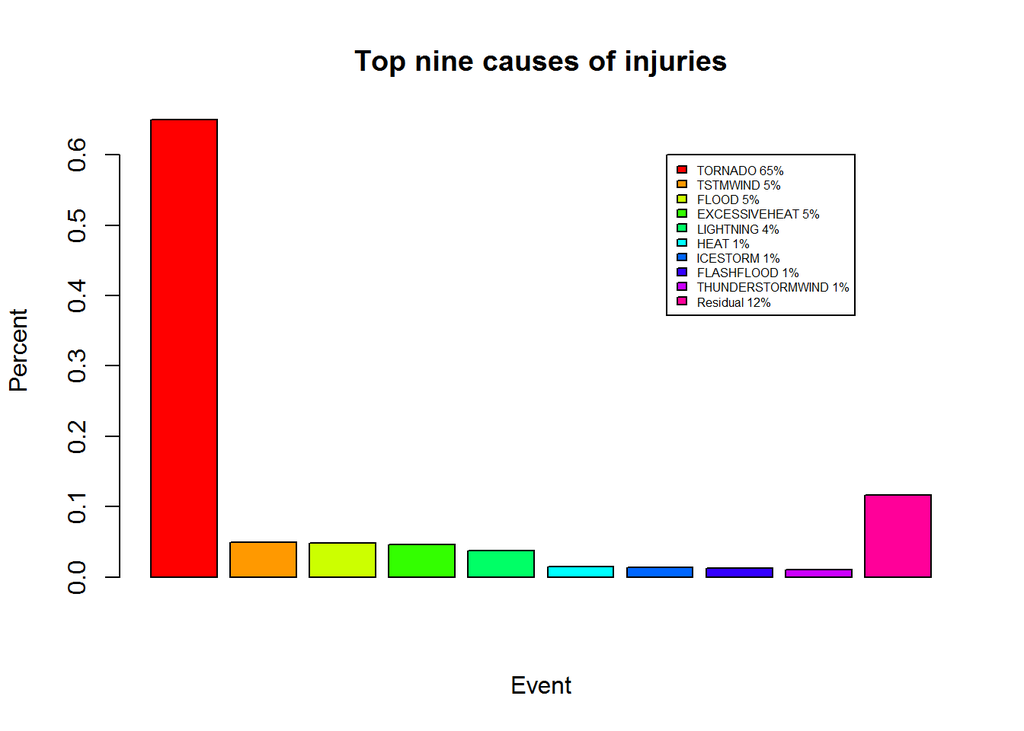

```r
barplot(slices_inj,main ="Top nine causes of injuries",xlab = "Event",ylab = c("Percent"),col = rainbow(length(labs_inj)))
legend(8,0.6,labs_inj,cex=0.5,pt.cex=0.3,fill= rainbow(length(labs_inj)))
```

The number of fatalities by storm event can be seen here.

```r
head(data_fatal)
```

```
## Source: local data frame [6 x 2]
##
##          EVTYPE FATALITIES
## 1       TORNADO       5633
## 2 EXCESSIVEHEAT       1903
## 3    FLASHFLOOD        978
## 4          HEAT        937
## 5     LIGHTNING        816
## 6      TSTMWIND        504
```

```r
length(data_fatal$EVTYPE)
```

```
## [1] 941
```

This in percentages is illustrated below.

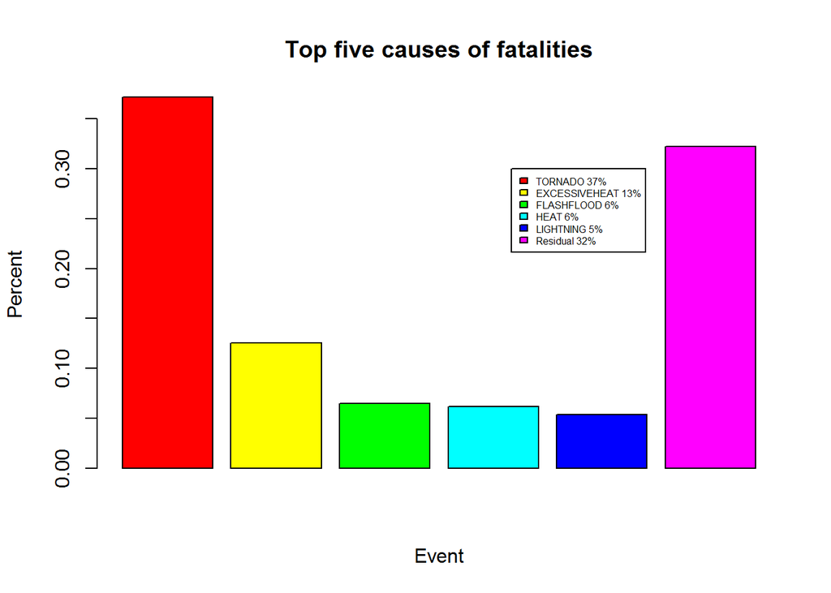

```r
barplot(slices_fat/tot_fat,main = "Top five causes of fatalities",xlab = "Event",ylab = c("Percent"),col = rainbow(length(labs_fat)))
legend(4.5,0.3,labs_fat,cex=0.5,pt.cex=0.3,fill=rainbow(length(labs_fat)))
```

The total cost (in dollars) of different types of storm events is as follows.

```r
head(data_cash)
```

```
## Source: local data frame [6 x 2]
##
##              EVTYPE        TCASH
## 1             FLOOD 149279651075
## 2 HURRICANE.TYPHOON  71908045673
## 3           TORNADO  54080855268
## 4        STORMSURGE  43304948611
## 5              HAIL  17502760918
## 6        FLASHFLOOD  15979926373
```

```r
length(data_cash$EVTYPE)
```

```
## [1] 941
```

In percentages this is.

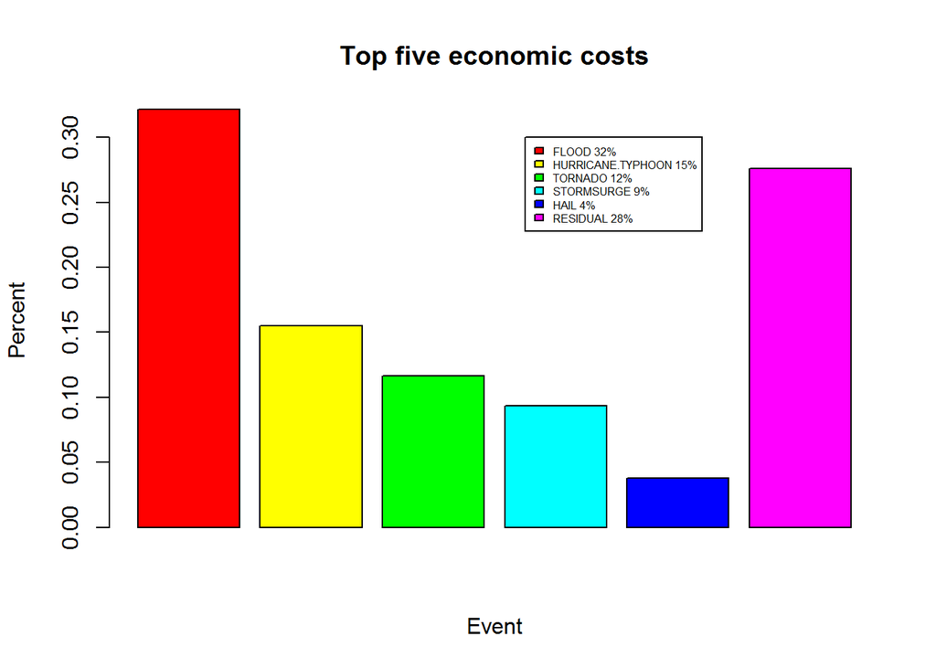

```r
barplot(slices_cash/tot_cash,main="Top five economic costs",xlab="Event",ylab="Percent",col = rainbow(length(labs_cash)))
legend(4,0.3,labs_cash,cex=0.5,pt.cex=0.3,fill=rainbow(length(labs_cash)))
```